# Example of PMM Aggregation

Niklas Dreiner

21.4.2020

## Imports

```r
##Datasets
require(mlbench) # to load example datasets from
require(titanic) # to load example datasets
#Model functions
require(xgboost) # xgboost modeler as an example
#Aggregation Functions
source("functionDefinitionsPMM.R")
```

## Generating the example dataset

We will simulate a multilabel dataset with differing amount of true labels and dependencies within two steps: * columnwise appending of multiple binary example datasets * to simulate inter-label dependencies, artifical labels dependent on logical connections between the other labels are added

```r
#titanic dataset
data(titanic_train)
df_titanic <- sample(titanic_train)
#Wisconsin breast cancer
data(BreastCancer)
df_wisconsinBreastcancer<-sample(BreastCancer)
#Pima Indians Diabetes Database
data(PimaIndiansDiabetes)
df_PimaIndiansDiabetes <- sample(PimaIndiansDiabetes)
# Sonar Database
data(Sonar)
df_Sonar <- sample(Sonar)


#unify data
n_shared_rows <- min(nrow(df_titanic),
                nrow(df_wisconsinBreastcancer),
                nrow(df_PimaIndiansDiabetes),
                nrow(df_Sonar))
df_total<-list(df_titanic,df_wisconsinBreastcancer,df_PimaIndiansDiabetes,df_Sonar)
df_total<-lapply(df_total, function(x){return(x[c(1:n_shared_rows),])})
df_total<-bind_cols(df_total)
#extract the labels and delete labels from dataset
c_lab_titanic <-(df_total[["Survived"]]==1)
c_lab_bc <- (df_total[["Class"]] =="malignant")
c_lab_pimaD <- (df_total[["diabetes"]]=="pos")
c_lab_sonar <- (df_total[["Class1"]]=="R")
df_total[,c("Survived","Class","diabetes","Class1")]<-list(NULL)
df_labels <- data.frame( SurvivedTitanic = c_lab_titanic,
                         HasBreastCancer = c_lab_bc,
                         HasDiabetes = c_lab_pimaD,
                         IsRock = c_lab_sonar
                         )
#add artifical labels in to simulate dependencies
df_labels$SurvivedTitanicANDHasBreastCancer<-df_labels$SurvivedTitanic & df_labels$HasBreastCancer
df_labels$SurvivedTitanicORHasBreastCancer<-df_labels$SurvivedTitanic | df_labels$HasBreastCancer
df_labels$SurvivedTitanicXORHasBreastCancer<-xor(df_labels$SurvivedTitanic,df_labels$HasBreastCancer)
df_labels$allNegative <-!(df_labels$SurvivedTitanic | df_labels$HasBreastCancer |df_labels$HasDiabetes |df_labels$IsRock)
df_labels$HasNoDiabetes <- !(df_labels$HasDiabetes)
#add random noise
df_labels$random_fifty_p_true <- sample(c(T,F),nrow(df_labels), replace = T)
df_labels$random_thirty_p_true <-sample(c(T,F),prob=c(0.3,0.7),nrow(df_labels), replace = T)
df_labels$random_ten_p_true <- sample(c(T,F),prob=c(0.1,0.9),nrow(df_labels), replace = T)

#delete Id columns
df_total[,c("Name","Cabin","PassengerId","Id","Ticket")]<-list(NULL)
#make char to factor
df_total$Embarked <- as.factor(df_total$Embarked)
df_total$Sex <- as.factor(df_total$Sex )
head(df_total)
```

```
##   Age    Fare Parch Embarked SibSp    Sex Pclass Cell.size Cl.thickness
## 1  22  7.2500     0        S     1   male      3         1            5
## 2  38 71.2833     0        C     1 female      1         4            5
## 3  26  7.9250     0        S     0 female      3         1            3
## 4  35 53.1000     0        S     1 female      1         8            6
## 5  35  8.0500     0        S     0   male      3         1            4
## 6  NA  8.4583     0        Q     0   male      3        10            8
##   Bl.cromatin Mitoses Bare.nuclei Marg.adhesion Cell.shape Normal.nucleoli
## 1           3       1           1             1          1               1
## 2           3       1          10             5          4               2
## 3           3       1           2             1          1               1
## 4           3       1           4             1          8               7
## 5           3       1           1             3          1               1
## 6           9       1          10             8         10               7
##   Epith.c.size age pedigree pregnant insulin glucose mass triceps pressure
```

[output cut: 48 more lines]

```r
head(df_labels)
```

```
##   SurvivedTitanic HasBreastCancer HasDiabetes IsRock
## 1           FALSE           FALSE        TRUE   TRUE
## 2            TRUE           FALSE       FALSE   TRUE
## 3            TRUE           FALSE        TRUE   TRUE
## 4            TRUE           FALSE       FALSE   TRUE
## 5           FALSE           FALSE        TRUE   TRUE
## 6           FALSE            TRUE       FALSE   TRUE
##   SurvivedTitanicANDHasBreastCancer SurvivedTitanicORHasBreastCancer
## 1                             FALSE                            FALSE
## 2                             FALSE                             TRUE
## 3                             FALSE                             TRUE
## 4                             FALSE                             TRUE
## 5                             FALSE                            FALSE
## 6                             FALSE                             TRUE
##   SurvivedTitanicXORHasBreastCancer allNegative HasNoDiabetes
## 1                             FALSE       FALSE         FALSE
## 2                              TRUE       FALSE          TRUE
## 3                              TRUE       FALSE         FALSE
## 4                              TRUE       FALSE          TRUE
## 5                             FALSE       FALSE         FALSE
## 6                              TRUE       FALSE          TRUE
##   random_fifty_p_true random_thirty_p_true random_ten_p_true
## 1                TRUE                 TRUE             FALSE
## 2                TRUE                 TRUE             FALSE
## 3               FALSE                FALSE             FALSE
## 4                TRUE                 TRUE             FALSE
## 5               FALSE                FALSE             FALSE
## 6                TRUE                FALSE             FALSE
```

## Train model

```r
p_testset<- 0.3
y_in_testset<-sample(c(T,F),size= nrow(df_total),prob = c(p_testset,1-p_testset),replace = T)
x_train<-df_total[!y_in_testset,]
x_test<-df_total[y_in_testset,]
y_train<- df_labels[!y_in_testset,]
y_test<-  df_labels[y_in_testset,]
```

```r
model<- pmmAggregation(df_labels=y_train,
                          data = data.matrix(x_train),
                          indiv_model_function=xgboost,
                          indiv_model_function_args=list(data=data.matrix(x_train),nrounds=2,params=list(eta=0.5,gamma=4,max_depth=10),verbose=0),
                          indiv_label_argName="label",
                          indiv_prediction_function=predict,
                          indiv_prediction_args=NULL,
                          indpred_arg_name_modelobj="object",
                          indpred_arg_name_newdata="newdata",
                          .progress="time",
                          .parallel=F
)
```

```
## [1] "Training models:"
##
|====                                                |8.333333% ~0 s remaining
|========                                            |16.66667% ~0 s remaining
|=================                                   |33.33333% ~0 s remaining
|=====================                               |41.66667% ~0 s remaining
|==============================                      |58.33333% ~0 s remaining
|==================================                  |66.66667% ~0 s remaining
|===========================================         |83.33333% ~0 s remaining
|===============================================     |91.66667% ~0 s remaining
|====================================================|100% ~0 s remaining
|====================================================|100%                      Completed after 0 s
## [1] "Generating prediction Dataframe:"
##
|====                                                |8.333333% ~0 s remaining
|========                                            |16.66667% ~0 s remaining
|=================                                   |33.33333% ~0 s remaining
|=====================                               |41.66667% ~0 s remaining
|==============================                      |58.33333% ~0 s remaining
|==================================                  |66.66667% ~0 s remaining
|===========================================         |83.33333% ~0 s remaining
|===============================================     |91.66667% ~0 s remaining
|====================================================|100% ~0 s remaining
|====================================================|100%                      Completed after 0 s
```

```r
head(model$df_predictions)
```

```
##   SurvivedTitanic HasBreastCancer HasDiabetes    IsRock
## 1       0.2719370       0.1404077   0.3531317 0.6192556
## 2       0.5530594       0.8043672   0.3531317 0.3378453
## 3       0.5530594       0.1404077   0.6633672 0.3378453
## 4       0.5530594       0.8043672   0.3531317 0.6192556
## 5       0.2719370       0.1404077   0.3531317 0.6192556
## 6       0.2719370       0.1404077   0.3531317 0.3378453
##   SurvivedTitanicANDHasBreastCancer SurvivedTitanicORHasBreastCancer
## 1                         0.2326485                        0.2819017
## 2                         0.2326485                        0.8498504
## 3                         0.2326485                        0.6211258
## 4                         0.2326485                        0.8498504
## 5                         0.2326485                        0.2819017
## 6                         0.2326485                        0.2819017
##   SurvivedTitanicXORHasBreastCancer allNegative HasNoDiabetes
## 1                         0.3137081   0.2485308     0.6468683
## 2                         0.5624019   0.2485308     0.6468683
## 3                         0.6279322   0.2485308     0.3366328
## 4                         0.5624019   0.2485308     0.6468683
## 5                         0.3137081   0.2485308     0.6468683
## 6                         0.3137081   0.2485308     0.6468683
##   random_fifty_p_true random_thirty_p_true random_ten_p_true
## 1           0.5079411            0.3491185         0.1955899
## 2           0.5079411            0.3491185         0.1955899
## 3           0.5079411            0.3491185         0.1955899
## 4           0.5079411            0.3491185         0.1955899
## 5           0.5079411            0.3491185         0.1955899
## 6           0.5079411            0.3491185         0.1955899
```

```r
model$vec_AUC
```

```
##  [1] 0.7852624 0.9704918 0.6810717 0.7854099 0.5000000 0.9235294 0.7787449
##  [8] 0.5000000 0.6810717 0.5000000 0.5000000 0.5000000
```

```r
model$vec_W
```

```
##  [1] 0.3254986 0.8854501 0.1311479 0.3258353 0.0000000 0.7175087 0.3107950
##  [8] 0.0000000 0.1311479 0.0000000 0.0000000 0.0000000
```

We can return a prediction in a form of matrix, or in a form of a nearest neighbour dataframe

```r
#NOTE:
#right now, the prediction  can handle only matrix like input
#return prediction matrix
df_prediction_matrix <-predict.pmmAggregation(model,data.matrix(x_test),k=1000,str_returnType = "m_pred")
df_prediction_knn <-predict.pmmAggregation(model,data.matrix(x_test),k=1000,str_returnType = "knn",y_include_distances=T)
```

```r
head(df_prediction_matrix)
```

```
##   SurvivedTitanic HasBreastCancer HasDiabetes    IsRock
## 1       0.2719370       0.1404077   0.3531317 0.3378453
## 2       0.2719370       0.8043672   0.3531317 0.3378453
## 3       0.5530594       0.1404077   0.6633672 0.6192556
## 4       0.5530594       0.1404077   0.3531317 0.6192556
## 5       0.5530594       0.8043672   0.3531317 0.3378453
## 6       0.5530594       0.8043672   0.3531317 0.6192556
##   SurvivedTitanicANDHasBreastCancer SurvivedTitanicORHasBreastCancer
## 1                         0.2326485                        0.2819017
## 2                         0.2326485                        0.8498504
## 3                         0.2326485                        0.6211258
## 4                         0.2326485                        0.6211258
## 5                         0.2326485                        0.8498504
## 6                         0.2326485                        0.8498504
##   SurvivedTitanicXORHasBreastCancer allNegative HasNoDiabetes
## 1                         0.3137081   0.2485308     0.6468683
## 2                         0.5624019   0.2485308     0.6468683
## 3                         0.6279322   0.2485308     0.3366328
## 4                         0.6279322   0.2485308     0.6468683
## 5                         0.5624019   0.2485308     0.6468683
## 6                         0.5624019   0.2485308     0.6468683
##   random_fifty_p_true random_thirty_p_true random_ten_p_true
## 1           0.5079411            0.3491185         0.1955899
## 2           0.5079411            0.3491185         0.1955899
## 3           0.5079411            0.3491185         0.1955899
## 4           0.5079411            0.3491185         0.1955899
## 5           0.5079411            0.3491185         0.1955899
## 6           0.5079411            0.3491185         0.1955899
```

Let us see how many of those predictions are illogical.

```r
#tranndformatrion of the prediction matrix containing p(TRUE) to bool values
df_prediction_matrix_bool <- as.data.frame(apply(df_prediction_matrix,c(1,2),function(x){return(x>=0.5)}))
ls_y_Islogical<-list()
ls_y_Islogical[[1]] <- (df_prediction_matrix_bool$SurvivedTitanic & df_prediction_matrix_bool$HasBreastCancer) == df_prediction_matrix_bool$SurvivedTitanicANDHasBreastCancer
ls_y_Islogical[[2]] <- (df_prediction_matrix_bool$SurvivedTitanic | df_prediction_matrix_bool$HasBreastCancer) == df_prediction_matrix_bool$SurvivedTitanicORHasBreastCancer
ls_y_Islogical[[3]]<- xor(df_prediction_matrix_bool$SurvivedTitanic,df_prediction_matrix_bool$HasBreastCancer) == df_prediction_matrix_bool$SurvivedTitanicXORHasBreastCancer
ls_y_Islogical[[4]] <- (df_prediction_matrix_bool$HasDiabetes=!df_prediction_matrix_bool$HasNoDiabetes)
ls_y_Islogical[[5]]<-!(df_prediction_matrix_bool$SurvivedTitanic | df_prediction_matrix_bool$HasBreastCancer |df_prediction_matrix_bool$HasDiabetes |df_prediction_matrix_bool$IsRock) == df_prediction_matrix_bool$allNegative
table(unlist(ls_y_Islogical))
```

```
##
## FALSE  TRUE
##    98   237
```

As we can see there are illogical statements made by the raw prediction, when each classifier classifies the dimensions independently. 29.2537313 % of the predicted interdependent labels are in conflict with another label of the description. This could be for example when the classifier predicts that the patient has Diabetes and Has Not Diabetes at the same time.

pmm.Aggregation tries to alleviate this problem. It tries to find instances in its training data model_object$df_labels, in ehich ist predicted similar values to the current prediction. This is done by a lookup in model_object$df_predictions. It displays these results in form of a dataframe:

```r
head(df_prediction_knn)
```

```
##   k index_input index_df_predictions  distance
## 1 1           1                   78 0.0000000
## 2 2           1                  104 0.0000000
## 3 3           1                  107 0.0000000
## 4 4           1                   93 0.0000000
## 5 5           1                   96 0.0000000
## 6 6           1                   71 0.1588866
```

## Evaluate the model

```r
#evaluate.pmmAggregation(model,testing_predictions= df_prediction_matrix ,k=1000,str_returnType = "m_pred"),testing_df_label = y_test)
eval <-evaluate.pmmAggregation(model,testing_predictions= predict.pmmAggregation(model,data.matrix(x_test),k=1000,str_returnType = "m_pred"),testing_df_label = y_test)
eval
```

```
## # A tibble: 141 x 3
##        k t_value t_value_perfect
##    <int>   <dbl>           <dbl>
##  1     1   -13.8           -24.4
##  2     2   -20.7           -26.1
##  3     3   -18.3           -24.5
##  4     4   -17.9           -27.9
##  5     5   -19.1           -28.7
##  6     6   -18.8           -30.3
##  7     7   -18.8           -31.3
##  8     8   -18.3           -30.8
##  9     9   -18.1           -30.5
## 10    10   -20.2           -31.7
## # ... with 131 more rows
```

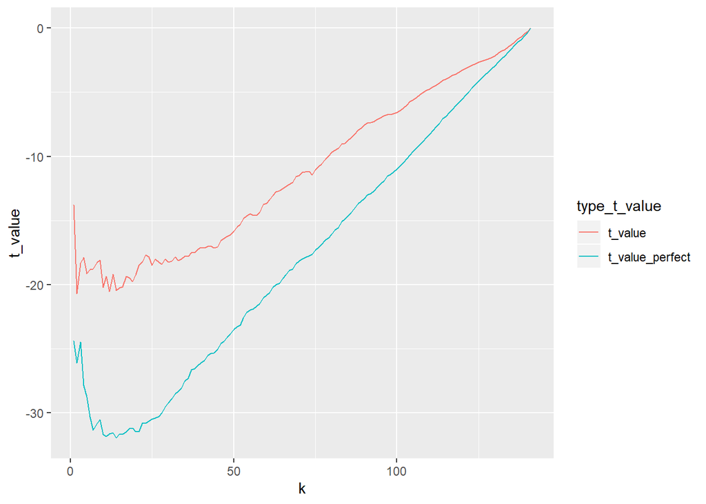

```r
evalplot1<-gather(eval,key="type_t_value", value="t_value",-k)
ggplot(evalplot1,aes(x=k,y=t_value,color=type_t_value))+geom_line()
```

```r
WEIGHT_P_TO_TRY <-c(0,1.2,1:8,10,20)
df_comparison_p <-llply(WEIGHT_P_TO_TRY,
                        .fun =function(x){
                          model<- pmmAggregation(df_labels=y_train,
                                                 data = data.matrix(x_train),
                                                 p=x,
                                                 indiv_model_function=xgboost,
                                                 indiv_model_function_args=list(data=data.matrix(x_train),
                                                                                nrounds=2,
                                                                                params=list(eta=0.5,
                                                                                            gamma=4,
                                                                                            max_depth=10),
                                                                                verbose=0),
                                                 indiv_label_argName="label",
                                                 indiv_prediction_function=predict,
                                                 indiv_prediction_args=NULL,
                                                 indpred_arg_name_modelobj="object",
                                                 indpred_arg_name_newdata="newdata",
                                                 .progress="none",
                                                 .parallel=F
                          )
                          result<-evaluate.pmmAggregation(model,
                                                          predict.pmmAggregation(model,
                                                                                 data.matrix(x_test),
                                                                                 str_returnType = "m_pred"
                                                                                 ),
                                                          y_test)
                          result$p_of_weighting<-x
                          return(result)
                        },
                        .progress="time"
)
```

```
##
|====                                                |8.333333% ~6 s remaining
|========                                            |16.66667% ~5 s remaining
|=================                                   |33.33333% ~4 s remaining
|=====================                               |41.66667% ~4 s remaining
|==============================                      |58.33333% ~3 s remaining
|==================================                  |66.66667% ~2 s remaining
|===========================================         |83.33333% ~1 s remaining
|===============================================     |91.66667% ~1 s remaining
|====================================================|100% ~0 s remaining
|====================================================|100%                      Completed after 6 s
```

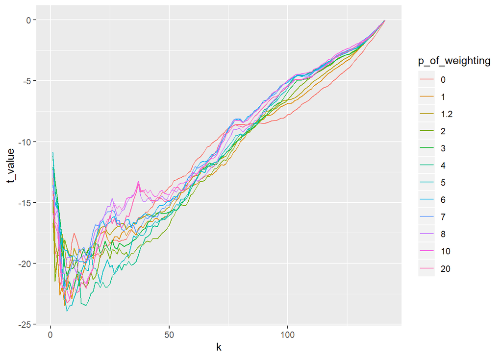

```r
df_comparison_p<- bind_rows(df_comparison_p)

eval_pplot<-df_comparison_p[c("k","p_of_weighting","t_value")]
eval_pplot$p_of_weighting<-as.factor(eval_pplot$p_of_weighting)
ggplot(eval_pplot,aes(x=k,y=t_value,color=p_of_weighting))+geom_line()
```

This is slower than needed. As we only need to manipulate the distance calculation, an update of the weights vector is sufficient. We do not need to retrain the model itself. This is done using the function `update_weights`.

```r
model_fast<- pmmAggregation(df_labels=y_train,
                                                 data = data.matrix(x_train),
                                                 p=2,
                                                 indiv_model_function=xgboost,
                                                 indiv_model_function_args=list(data=data.matrix(x_train),
                                                                                nrounds=2,
                                                                                params=list(eta=0.5,
                                                                                            gamma=4,
                                                                                            max_depth=10),
                                                                                verbose=0),
                                                 indiv_label_argName="label",
                                                 indiv_prediction_function=predict,
                                                 indiv_prediction_args=NULL,
                                                 indpred_arg_name_modelobj="object",
                                                 indpred_arg_name_newdata="newdata",
                                                 .progress="none",
                                                 .parallel=F
                          )
df_comparison_p <-llply(WEIGHT_P_TO_TRY,
                        .fun =function(x){
                          model_fast<-update_weights(model = model_fast,p=x)
                          result<-evaluate.pmmAggregation(model_fast,
                                                          predict.pmmAggregation(model_fast,
                                                                                 data.matrix(x_test),
                                                                                 str_returnType = "m_pred"),
                                                          y_test)
                          result$p_of_weighting<-x
                          return(result)
                        },
                        .progress="time"
)
```

```
##
|====                                                |8.333333% ~4 s remaining
|========                                            |16.66667% ~3 s remaining
|=================                                   |33.33333% ~3 s remaining
|=====================                               |41.66667% ~2 s remaining
|==============================                      |58.33333% ~2 s remaining
|==================================                  |66.66667% ~1 s remaining
|===========================================         |83.33333% ~1 s remaining
|===============================================     |91.66667% ~0 s remaining
|====================================================|100% ~0 s remaining
|====================================================|100%                      Completed after 4 s
```

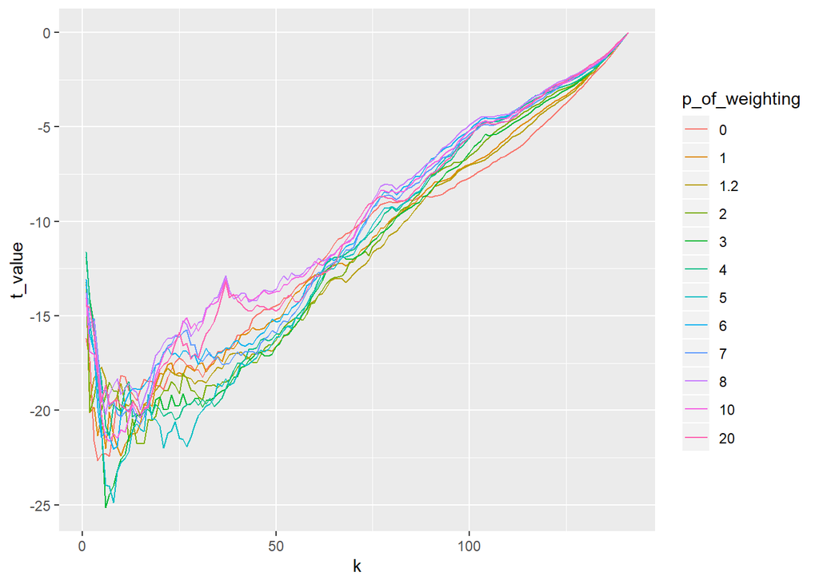

```r
df_comparison_p<- bind_rows(df_comparison_p)

eval_pplot_fast<-df_comparison_p[c("k","p_of_weighting","t_value")]
eval_pplot_fast$p_of_weighting<-as.factor(eval_pplot_fast$p_of_weighting)
ggplot(eval_pplot_fast,aes(x=k,y=t_value,color=p_of_weighting))+geom_line()
```

### Custom models and functions

PMM Aggregation accepts any model under the following conditions:

- The model can classify binary $label \in {TRUE, FALSE}$ to be evaluated via AUC.
- the output of the prediction function is the probability of the label being True : $p(IsTrue)$
- Output of the training model can have the following output:
  - model_object
  - `list(model=model_object, AUC= .auc_calculated)`: In this Case, the AUC value provided will be the AUC value given to the weight calculation concerning this label dimension.

The following Code is an example of a custom training function: The function adds cv as well as gridsearch to the xgboost training

```r
#enabling xgboost with cv, gridsearch and automatic AUC Control as example for a custom train function usable with pmm.Aggregation
custom_xgboost<-function(train_data,
                         custom_label_arg_name,
                         grid_xgb,cv_folds,
                         nrounds){
  ls_params_performance<-apply(grid_xgb,1,function(params){
                        current_params=list(eta=params[['eta']],
                        max_depth=params[['max_depth']],
                        gamma=params[['gamma']],
                        colsample_bytree=params[['colsample_bytree']],
                        subsample=params[['subsample']]
    )

    xgboost_cv<-xgb.cv(data=train_data,
                       label=custom_label_arg_name,
                       objective="binary:logistic",
                       nfold = cv_folds,
                       nrounds = nrounds,
                       params = current_params,
                       metrics= "auc",
                       stratified = T,
                       verbose=F
    )
    eval_log <-xgboost_cv$evaluation_log
    eval_log <- eval_log %>% arrange(desc(test_auc_mean))
    result_auc<-eval_log$test_auc_mean[1]
    best_iteration_number <- eval_log$iter[1]
    return(list(result_auc=result_auc,best_iteration_number=best_iteration_number,params=current_params))
  }
  )
  #get best params
  ls_unlistet_auc <- lapply(ls_params_performance,'[[',"result_auc") #extract result_auc
  ls_unlistet_auc <- unlist(ls_unlistet_auc)#make to vector
  index_best_params<-which(ls_unlistet_auc==max(ls_unlistet_auc))[1]
  #train final on the whole train set with the best parameters
  result_model<-xgboost(data=train_data,
                       label=custom_label_arg_name,
                       objective="binary:logistic",
                       nrounds = ls_params_performance[[index_best_params]]$best_iteration_number,
                       params = ls_params_performance[[index_best_params]]$params,
                       verbose = F)
  #Return statement: IMPORTANT, names and order of the list are extremly important to pmm.Aggregation
  return(list(model=result_model,
              AUC=ls_unlistet_auc[index_best_params])
         )
}
```

```r
gridsearch_table <- expand.grid(eta=c(0.1,0.3),
                               max_depth=c(3,6),
                               gamma=c(1,5),
                               colsample_bytree=c(0.5,1),
                               subsample=c(0.8,1))

aggregated_model <- pmmAggregation(df_labels=y_train,
                                   data = data.matrix(x_train),
                                   p=2,
                                   indiv_model_function=custom_xgboost,
                                   indiv_model_function_args=list(train_data=data.matrix(x_train),
                                                                  cv_folds=2,
                                                                  nrounds=10,
                                                                  grid_xgb=gridsearch_table
                                                                  ),
                                   indiv_label_argName="custom_label_arg_name",
                                   indiv_prediction_function=predict,
                                   indiv_prediction_args=NULL,
                                   indpred_arg_name_modelobj="object",
                                   indpred_arg_name_newdata="newdata",
                                   .progress="time",
                                   .parallel=F
)
```

```
## [1] "Training models:"
##
|====                                                |8.333333% ~25 s remaining
|========                                            |16.66667% ~20 s remaining
|=================                                   |33.33333% ~17 s remaining
|=====================                               |41.66667% ~15 s remaining
|==============================                      |58.33333% ~11 s remaining
|==================================                  |66.66667% ~9 s remaining
|===========================================         |83.33333% ~4 s remaining
|===============================================     |91.66667% ~2 s remaining
|====================================================|100% ~0 s remaining
|====================================================|100%                      Completed after 26 s
## [1] "Generating prediction Dataframe:"
##
|====                                                |8.333333% ~0 s remaining
|========                                            |16.66667% ~0 s remaining
|=================                                   |33.33333% ~0 s remaining
|=====================                               |41.66667% ~0 s remaining
|==============================                      |58.33333% ~0 s remaining
|==================================                  |66.66667% ~0 s remaining
|===========================================         |83.33333% ~0 s remaining
|===============================================     |91.66667% ~0 s remaining
|====================================================|100% ~0 s remaining
|====================================================|100%                      Completed after 0 s
```

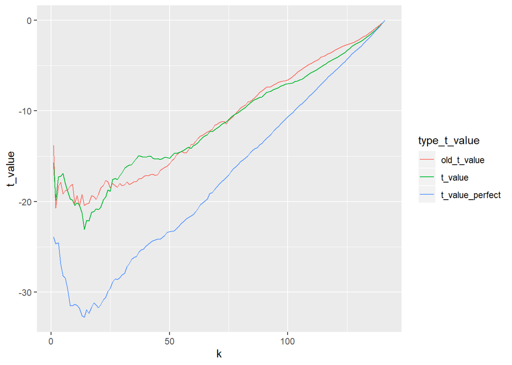

```r
eval <-evaluate.pmmAggregation(aggregated_model,
                               testing_predictions= predict.pmmAggregation(aggregated_model,data.matrix(x_test),str_returnType = "m_pred"),
                               testing_df_label = y_test)
evalplot2<-gather(eval,key="type_t_value", value="t_value",-k) %>% rbind(.,filter(evalplot1,type_t_value=="t_value") %>% mutate(.,type_t_value="old_t_value"))
ggplot(evalplot2,aes(x=k,y=t_value,color=type_t_value))+geom_line()
```

To demonstrate a Model other than xgboost, we will use logistic regression as an alternative.

```r
#glm is a bit of a pain as it forces usage of a formula. glm.fit(x,y) will break at prediction)
glm_custom<-function(x,y){
  label <- y
  data <- cbind(x,label)
  data <- as.data.frame(data.matrix(data))
  glm_model<-glm(formula=label~.,data=data,family = "binomial", y=F,model = F)
  return(glm_model)
}

glm_predict <- function(model_object,x){
  data <-as.data.frame(data.matrix(x))
  result<-predict.glm(object=model_object,newdata=data, type="response")
  return(result)
}
```

```r
#logreg cannot handle na values. We will delete all rows in the dataset with an NA Entry
train_row_NoNA <- apply(x_train,1,FUN = function(x){all(!is.na(x))})
aggregated_model_logreg <- pmmAggregation(df_labels=y_train[train_row_NoNA,],
                                   data = x_train[train_row_NoNA,],
                                   indiv_model_function=glm_custom,
                                   indiv_model_function_args=list(x=x_train[train_row_NoNA,]),
                                   indiv_label_argName="y",
                                   indiv_prediction_function=glm_predict,
                                   indiv_prediction_args=NULL,
                                   indpred_arg_name_modelobj="model_object",
                                   indpred_arg_name_newdata="x",
                                   .progress="time",
                                   .parallel=F
)
```

```
## [1] "Training models:"
##
|====                                                |8.333333% ~0 s remaining
|========                                            |16.66667% ~0 s remaining
|=================                                   |33.33333% ~0 s remaining
|=====================                               |41.66667% ~0 s remaining
|==============================                      |58.33333% ~0 s remaining
|==================================                  |66.66667% ~0 s remaining
|===========================================         |83.33333% ~0 s remaining
|===============================================     |91.66667% ~0 s remaining
|====================================================|100% ~0 s remaining
|====================================================|100%                      Completed after 0 s
## [1] "Generating prediction Dataframe:"
##
|====                                                |8.333333% ~0 s remaining
|========                                            |16.66667% ~0 s remaining
|=================                                   |33.33333% ~0 s remaining
|=====================                               |41.66667% ~0 s remaining
|==============================                      |58.33333% ~0 s remaining
|==================================                  |66.66667% ~0 s remaining
|===========================================         |83.33333% ~0 s remaining
|===============================================     |91.66667% ~0 s remaining
|====================================================|100% ~0 s remaining
|====================================================|100%                      Completed after 0 s
```

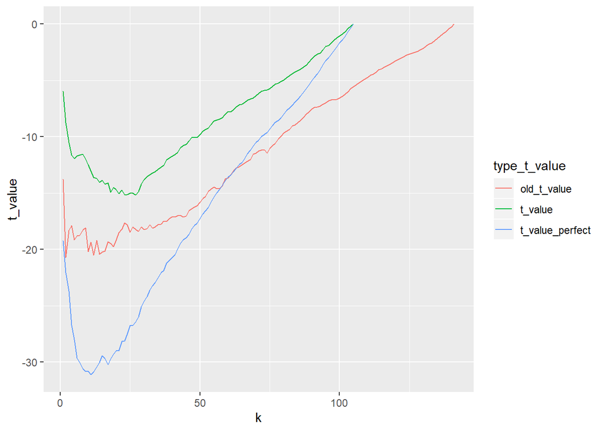

```r
test_row_NoNA <-apply(x_test,1,FUN = function(x){all(!is.na(x))})
eval <-evaluate.pmmAggregation(aggregated_model_logreg,
                               testing_predictions= predict.pmmAggregation(aggregated_model_logreg,x_test[test_row_NoNA,],str_returnType = "m_pred"),
                               testing_df_label = y_test[test_row_NoNA,])
evalplot3<-gather(eval,key="type_t_value", value="t_value",-k) %>% rbind(.,filter(evalplot1,type_t_value=="t_value") %>% mutate(.,type_t_value="old_t_value"))
ggplot(evalplot3,aes(x=k,y=t_value,color=type_t_value))+geom_line()
```

Here we can see a problem concerning the evaluation. The evaluation cannot compare knn, where the amount of points in model$df_prediction differs from each other.